# Horse Racing Analysis

```r
#attempting to predict winner through glm
fitted.results <- predict(glm_winner,
                          newdata=test_horse_data,type='response')

#fitted.results <- ifelse(fitted.results > 0.5,1,0)
##oh no, glm dont predict any horses winning
glue("The GLM's largest prediction for a horse winning is {round(max(fitted.results)*100,2)}%")
```

```
The GLM's largest prediction for a horse winning is 26.03%
```

The GLM found no way to make any predictions where a horse would win, it was decided that we will try using a random forest to predict some winning horses via classification.

```r
library(randomForest)
#random forest
rf_winner <- randomForest(data = train_horse_data,winner ~ Bar. + Weight + track_condition + distance + odds, importance = TRUE)
# random forest model summary
rf_winner
```

```
Call:
 randomForest(formula = winner ~ Bar. + Weight + track_condition +      distance + odds, data = train_horse_data, importance = TRUE)
               Type of random forest: regression
                     Number of trees: 500
No. of variables tried at each split: 1

          Mean of squared residuals: 0.08349708
                    % Var explained: 9.69
```

```r
#predicting horse races on the test set
predTrain <- predict(rf_winner, test_horse_data, type = "class")
#converting the prediction probability to a simply win or no win
predTrain <- ifelse(predTrain>=0.5,1,0)

#table of predicted vs actual
cat("Predicted against actual results")
```

```
Predicted against actual results
```

```r
table(test_horse_data$winner,predTrain)
```

```
   predTrain
      0   1
  0 635   2
  1  63   1
```

```r
#randomforest model summary stats in sentence.
cat(glue("The Random forest does not predict a lot of horses to win (only {sum(predTrain==1)}), however its total accuracy of {round(mean(predTrain == test_horse_data$winner)*100,2)}% is quite impressive."))
```

```
The Random forest does not predict a lot of horses to win (only 3), however its total accuracy of 90.73% is quite impressive.
```

```r
#testing to see if betting on these races can be profitable
test_horse_data_rf_bet <- test_horse_data %>%
  mutate(pred = predTrain) %>%
  filter(pred == 1) %>%
  #calculating required bet amount to profit $100 if the horse wins
  mutate(bet = 100/(odds-1),
         profit = ifelse(winner==1,(bet*odds)-bet,-bet),
         roll_total = cumsum(profit))


reactable(test_horse_data_rf_bet %>%
        select(Horse,
               RaceID,
               Bar.,
               Weight,
               distance,
               track_condition,
               odds,
               winner,
               bet,
               profit,
               roll_total))
```

| Horse | RaceID | Bar. | Weight | distance | track_condition | odds | winner | bet | profit | roll_total |
| --- | --- | --- | --- | --- | --- | --- | --- | --- | --- | --- |
| MUSIC ADDITION | 2022May22,TAS,Hobart , Race 1 | 3 | 56 | 1100 | Track Condition: Soft 5 | 2.05 | 1 | 95.2380952380953 | 100 | 100 |
| CALMSIR (NZ) | 2022May22,VIC,Sportsbet-Wangaratta , Race 3 | 6 | 59.5 | 2000 | Track Condition: Soft 5 | 2.2 | 0 | 83.3333333333333 | -83.3333333333333 | 16.6666666666667 |
| THUNDER KNOB | 2022May22,NSW,Muswellbrook , Race 4 | 3 | 59 | 1280 | Track Condition: Heavy 10 | 2.6 | 0 | 62.5 | -62.5 | -45.8333333333333 |

Whilst we can see this random forest does predict accurately, we were hoping for better in the prediction department. Maybe if we use some machine learning we can get some better predictions. Lets have a look at how a neural network goes with predicting winning horses.

```r
#train_params <- trainControl(method = "repeatedcv", number = 3, repeats=2)
nn_train_df <- train_horse_data %>%
                      select(Bar.,Weight, track_condition, distance, odds)

nnet_model <- train(nn_train_df,
                    train_horse_data$winner,
                    method = "nnet",
                    #trControl= train_params,
                    na.action = na.omit
)
```

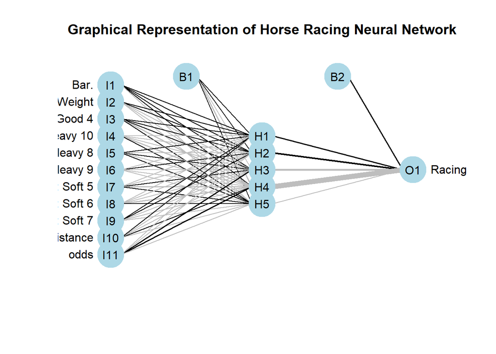

```r
#Predictions on the test set
nnet_predictions_test <-ifelse(predict(nnet_model, test_horse_data)>=0.5,1,0)

#plotting neuralnet to show
plotnet(nnet_model$finalModel, y_names = "Racing Factors")
title("Graphical Representation of Horse Racing Neural Network")
```

```r
# Confusion matrix on test set
table(test_horse_data$winner, nnet_predictions_test)
```

```
   nnet_predictions_test
      0   1
  0 636   1
  1  64   0
```

In future modifications of this analysis, more data will be used and a prediction on time will be analysed using factors such as the horse, trainer and jockey, however as most horses in this data only appear once, training a model on the horse, jockey and trainer is not useful, and may also be biased towards certain trainers and Jockeys who simply train/ride better horses due to their experience and success level (think of Gai Waterhouse and Damian Oliver as examples)

#### Making money

For this to work, the user would need a decent pool of available cash on hand, to sustain increasing bets until a winner pays out and returns all previous bets plus desired winnings. The other most important factor, would be that the better quits after winning their desired amount for that day. This essentially means that if the first favourite wins, the bettor is finished after one race for that day. If it takes 7 races for a favourite to win, the bettor will wager on all 7 races with increasing amounts until a winner emerges resulting in all outlayed bets repayed, along with the desired profit.

```r
#attempting to create a betting system on favourites where bets grow larger to recoup losses until a winner is picked providing the desired profit


daily_profit_function <- function(race_data, desired_profit_daily = 200){
fav_betting_system_df <- race_data %>%
  #only need favourites
  filter(favourite == 1) %>%
  #arranging by time to align with real life and multiple tracks on same day, and barrier to remove any horses where there are multiple favourites so only a single fav is chosen for each race
  arrange(Datetime, Bar.) %>%
  #selecting single fav for each race
  distinct(Datetime, .keep_all =T) %>%
  #calculating required bet wo win $200 of that race
  mutate(bet = NA,
         new_bet = NA,
         total_outlay = NA)

#calculating the bet amount for each individual race, and the total outlay, for races after an initial race has failed. so all bet amounts would be taken off the new_bet once this is complete
for (i in 1:nrow(fav_betting_system_df)){
  if (i==1){
    fav_betting_system_df$bet[[i]] <- 1
    fav_betting_system_df$new_bet[[i]] <- desired_profit_daily/(fav_betting_system_df$odds[[i]]-1)
    fav_betting_system_df$total_outlay[[i]] <- desired_profit_daily/(fav_betting_system_df$odds[[i]]-1)
  } else if(fav_betting_system_df$Date_format[[i]] != fav_betting_system_df$Date_format[[i-1]]) {
    fav_betting_system_df$bet[[i]] <- 1
    fav_betting_system_df$new_bet[[i]] <- desired_profit_daily/(fav_betting_system_df$odds[[i]]-1)
    fav_betting_system_df$total_outlay[[i]] <- desired_profit_daily/(fav_betting_system_df$odds[[i]]-1)
  } else {
    fav_betting_system_df$bet[[i]] <- ifelse(fav_betting_system_df$bet[[i-1]]==0,
                                             0,
                                             ifelse(fav_betting_system_df$winner[[i-1]]==1,
                                                    0,
                                                    1))
    fav_betting_system_df$new_bet[[i]] <- ifelse(fav_betting_system_df$bet[[i]]==1,(fav_betting_system_df$total_outlay[[i-1]]+desired_profit_daily)/(fav_betting_system_df$odds[[i]]-1),0)
    fav_betting_system_df$total_outlay[[i]] <- ifelse(fav_betting_system_df$bet[[i]]==1, (fav_betting_system_df$total_outlay[[i-1]]+fav_betting_system_df$new_bet[[i]]),0)
  }
}

return(fav_betting_system_df)
}

graph_daily_bets <- function(profit_data){
#quick plot of number of bets per day to get a winner
ggplot(profit_data %>% group_by(Date_format) %>%
          summarise(numbets_day = sum(bet))) +
   geom_line(aes(x=Date_format, y = numbets_day))+
    labs(title = "plot of number of bets per day to get a winner",
         x = "Date",
         y = "Number of daily bets required until a favourite wins")

}

graph_daily_profits <- function(profit_data){
#quick plot of maximum amount required for any single day of betting to get a winner over the previous month
ggplot(profit_data %>% group_by(Date_format) %>%
         summarise(maxbet = max(total_outlay))) +
   geom_line(aes(x=Date_format, y = maxbet))+
    labs(title = "plot of maximum amount required for any single day of betting to get a winner",
         x = "Date",
         y = "Total money required to 'double down'")
}

graph_total_profits <- function(profit_data){
  ggplot(profit_data %>%
           #filtering for only races we bet on now
            filter(bet ==1) %>%
            mutate(profits = ifelse(winner ==1,(new_bet*odds)-new_bet,-new_bet),
            roll_profits = cumsum(profits))) +
    geom_line(aes(x = Datetime, y = roll_profits))+
    labs(title = "accumulative profits through time",
         x = "Time",
         y = "Accumulative profits")
}

profit_system_df_function <- function(profit_data){
fav_betting_system_df_bets <- profit_data %>%
  #filtering for only races we bet on now
  filter(bet ==1) %>%
  mutate(profits = ifelse(winner ==1,(new_bet*odds)-new_bet,-new_bet),
         roll_profits = cumsum(profits))
return(fav_betting_system_df_bets)
}
```

Below a simulation on the last months worth of horse racing data has been run, and for different desired winning amounts, the amount of initial funds required obviously varies depending on the desired daily win amount. Below are runs of 50 dollars daily profit, 100 dollars daily profit, and 200 dollars daily profit

##### $50 profit Daily

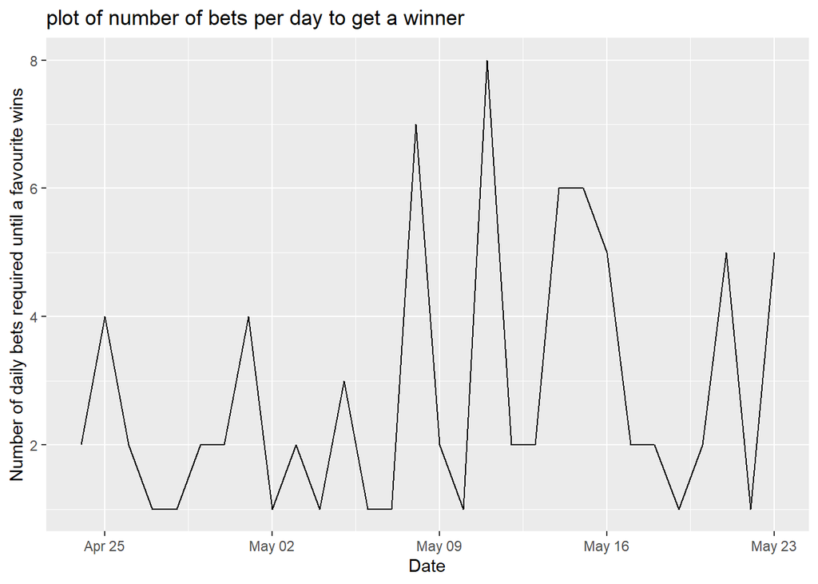

```r
profit_50_daily <- daily_profit_function(all_race_data_clean, 50)
graph_daily_bets(profit_50_daily)
```

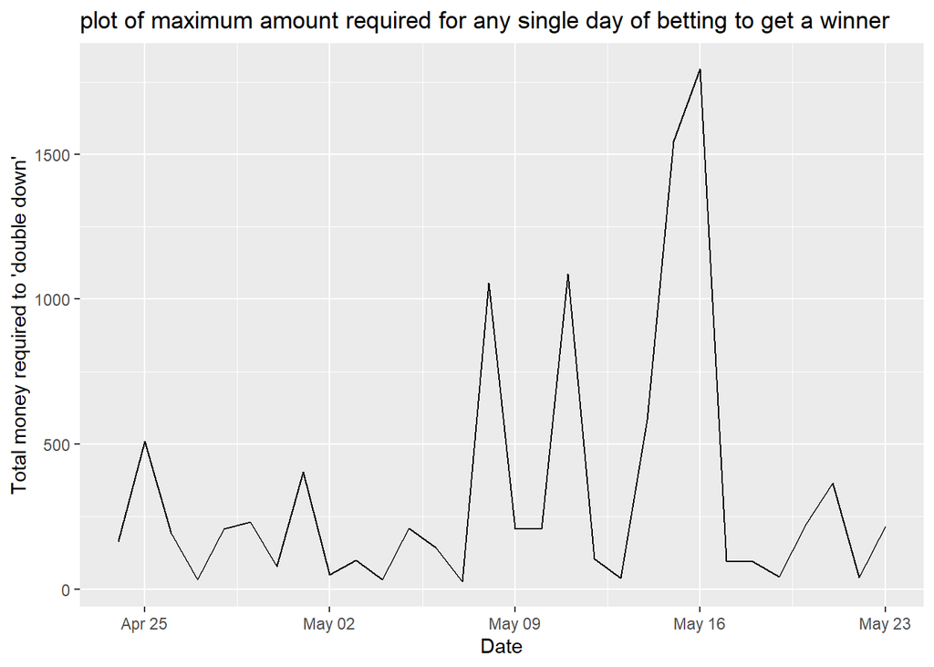

```r
graph_daily_profits(profit_50_daily)
```

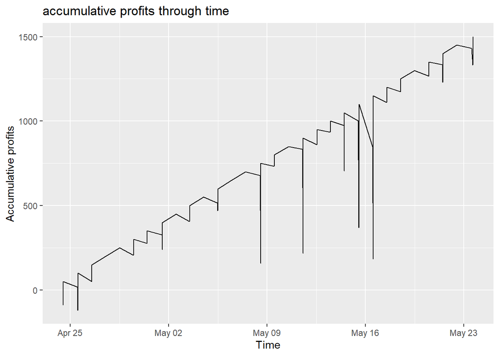

```r
graph_total_profits(profit_50_daily)
```

```r
reactable(profit_system_df_function(profit_50_daily) %>% select(-character,
                                                                -info,
                                                                -race_info))
```

| Finish | No. | Horse | Trainer | Jockey | Margin | Bar. | Weight | Starting.Price | odds | Date_format | State | Racecourse | Race | Day_of_week | distance | track_condition | Margin_Metres | time | RaceID | ID | winner | Race_time | Datetime | favourite | fav_winner | bet | new_bet | total_outlay | profits | … |
| --- | --- | --- | --- | --- | --- | --- | --- | --- | --- | --- | --- | --- | --- | --- | --- | --- | --- | --- | --- | --- | --- | --- | --- | --- | --- | --- | --- | --- | --- | --- |
| 7 | 7 | PIIINK BEAUTY | Glenn Stevenson | Ms Codi Jordan (a0/51kg) | 2.8 | 4 | 55 | $1.55F | 1.55 | 2022-04-24 | TAS | Hobart | Race 1 | Sun | 1200 | Track Condition: Good 4 | 7 | 74.9345833333333 | 2022Apr24,TAS,Hobart , Race 1 | 2022Apr24,TAS,Hobart , Race 1 Finish- 7 | 0 | 11:50AM | 2022-04-24T11:50:00 | 1 | 0 | 1 | 90.9090909090909 | 90.9090909090909 | -90.9090909090909 | … |
| 1 | 10 | BEZIQUE | Tony Gollan | Ben Thompson |  | 8 | 55 | $2.90F | 2.9 | 2022-04-24 | QLD | Sunshine Coast | Race 1 | Sun | 1000 | Track Condition: Soft 7 | 0 | 60.64 | 2022Apr24,QLD,Sunshine Coast , Race 1 | 2022Apr24,QLD,Sunshine Coast , Race 1 Finish- 1 | 1 | 11:55AM | 2022-04-24T11:55:00 | 1 | 1 | 1 | 74.1626794258373 | 165.071770334928 | 140.909090909091 | … |
| 3 | 7 | POPPY’S GIRL | Gary Portelli | Ms Alysha Collett | 0.85 | 2 | 55 | $2.50F | 2.5 | 2022-04-25 | NSW | Gosford | Race 1 | Mon | 1200 | Track Condition: Heavy 9 | 2.125 | 74.9124229166667 | 2022Apr25,NSW,Gosford , Race 1 | 2022Apr25,NSW,Gosford , Race 1 Finish- 3 | 0 | 12:29PM | 2022-04-25T12:29:00 | 1 | 0 | 1 | 33.3333333333333 | 33.3333333333333 | -33.3333333333333 | … |
| 4 | 8 | HEADLINER | Chris Waller | James McDonald | 2.06 | 5 | 55 | $2.60F | 2.6 | 2022-04-25 | NSW | Kensington | Race 1 | Mon | 1100 | Track Condition: Heavy 9 | 5.15 | 68.1475677272727 | 2022Apr25,NSW,Kensington , Race 1 | 2022Apr25,NSW,Kensington , Race 1 Finish- 4 | 0 | 12:45PM | 2022-04-25T12:45:00 | 1 | 0 | 1 | 52.0833333333333 | 85.4166666666667 | -52.0833333333333 | … |
| 6 | 2 | ROUSSEAU | Chris Waller | Craig Williams | 17 | 4 | 53 | $2.60F | 2.6 | 2022-04-25 | VIC | Flemington | Race 1 | Mon | 2600 | Track Condition: Good 4 | 42.5 | 165.532298076923 | 2022Apr25,VIC,Flemington , Race 1 | 2022Apr25,VIC,Flemington , Race 1 Finish- 6 | 0 | 1:00PM | 2022-04-25T13:00:00 | 1 | 0 | 1 | 84.6354166666667 | 170.052083333333 | -84.6354166666667 | … |
| 1 | 6 | MISS MAZ | Gerald Ryan & Sterling Alexiou | Ms Alysha Collett |  | 2 | 56.5 | $1.65F | 1.65 | 2022-04-25 | NSW | Gosford | Race 2 | Mon | 1000 | Track Condition: Heavy 9 | 0 | 61.52 | 2022Apr25,NSW,Gosford , Race 2 | 2022Apr25,NSW,Gosford , Race 2 Finish- 1 | 1 | 1:04PM | 2022-04-25T13:04:00 | 1 | 1 | 1 | 338.541666666667 | 508.59375 | 220.052083333333 | … |
| 2 | 5 | SKY ACE | Brad Widdup | Ms Alysha Collett | 2 | 3 | 55 | $2F | 2 | 2022-04-26 | NSW | Nowra | Race 1 | Tue | 2200 | Track Condition: Heavy 10 | 5 | 145.820659090909 | 2022Apr26,NSW,Nowra , Race 1 | 2022Apr26,NSW,Nowra , Race 1 Finish- 2 | 0 | 12:55PM | 2022-04-26T12:55:00 | 1 | 0 | 1 | 50 | 50 | -50 | … |
| 1 | 3 | AQUILA VOLARE | Ciaron Maher & David Eustace | Harry Coffey |  | 6 | 59 | $1.70F | 1.7 | 2022-04-26 | VIC | bet365 Mildura | Race 1 | Tue | 2000 | Track Condition: Soft 5 | 0 | 130.23 | 2022Apr26,VIC,bet365 Mildura , Race 1 | 2022Apr26,VIC,bet365 Mildura , Race 1 Finish- 1 | 1 | 1:00PM | 2022-04-26T13:00:00 | 1 | 1 | 1 | 142.857142857143 | 192.857142857143 | 100 | … |
| 1 | 3 | LETHAL THOUGHTS | Ciaron Maher & David Eustace | Ben Allen |  | 3 | 58 | $2.50F | 2.5 | 2022-04-27 | VIC | Sale | Race 1 | Wed | 1206 | Track Condition: Soft 5 | 0 | 71.65 | 2022Apr27,VIC,Sale , Race 1 | 2022Apr27,VIC,Sale , Race 1 Finish- 1 | 1 | 12:25PM | 2022-04-27T12:25:00 | 1 | 1 | 1 | 33.3333333333333 | 33.3333333333333 | 50 | … |
| 1 | 7 | AFRICAN DAISY | Annabel Neasham | Brodie Loy |  | 6 | 56.5 | $1.24F | 1.24 | 2022-04-28 | NSW | Wyong | Race 1 | Thu | 1350 | Track Condition: Heavy 10 | 0 | 82.32 | 2022Apr28,NSW,Wyong , Race 1 | 2022Apr28,NSW,Wyong , Race 1 Finish- 1 | 1 | 12:20PM | 2022-04-28T12:20:00 | 1 | 1 | 1 | 208.333333333333 | 208.333333333333 | 50 | … |

[output cut: 74 more lines]

##### $100 profit Daily

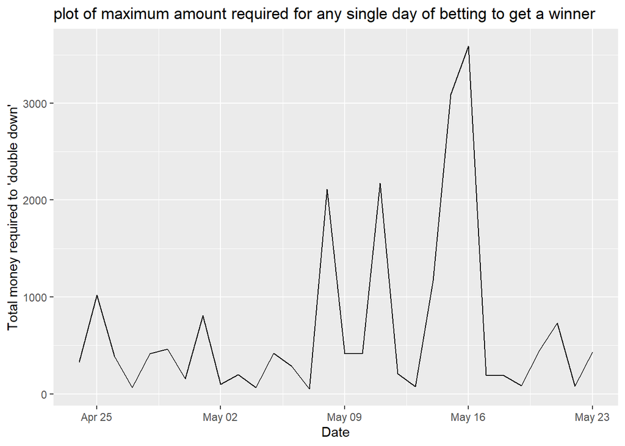

```r
profit_100_daily <- daily_profit_function(all_race_data_clean, 100)
graph_daily_profits(profit_100_daily)
```

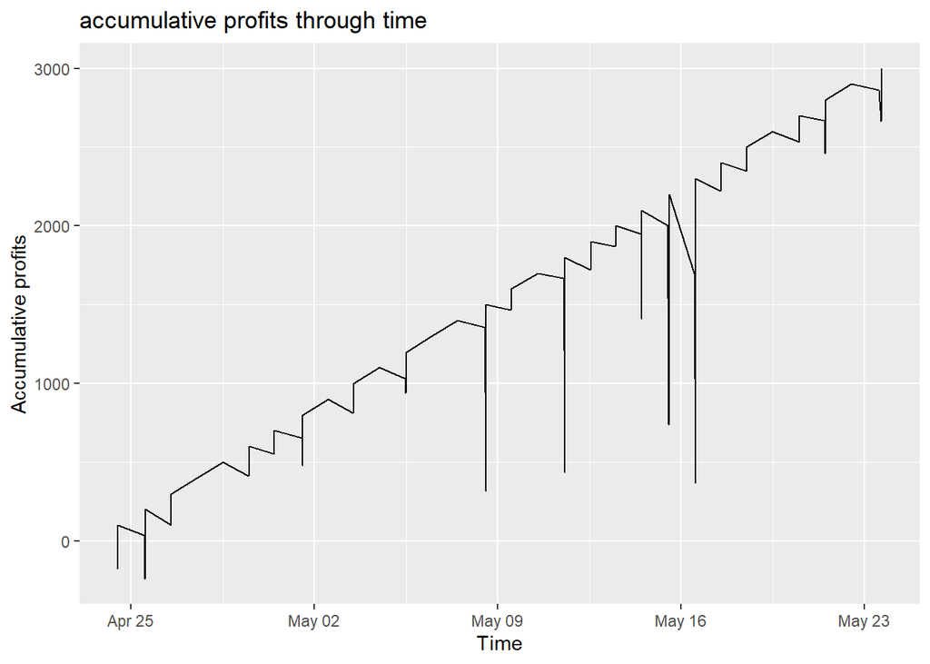

```r
graph_total_profits(profit_100_daily)
```

```r
reactable(profit_system_df_function(profit_100_daily) %>% select(-character,
                                                                -info,
                                                                -race_info))
```

| Finish | No. | Horse | Trainer | Jockey | Margin | Bar. | Weight | Starting.Price | odds | Date_format | State | Racecourse | Race | Day_of_week | distance | track_condition | Margin_Metres | time | RaceID | ID | winner | Race_time | Datetime | favourite | fav_winner | bet | new_bet | total_outlay | profits | … |
| --- | --- | --- | --- | --- | --- | --- | --- | --- | --- | --- | --- | --- | --- | --- | --- | --- | --- | --- | --- | --- | --- | --- | --- | --- | --- | --- | --- | --- | --- | --- |
| 7 | 7 | PIIINK BEAUTY | Glenn Stevenson | Ms Codi Jordan (a0/51kg) | 2.8 | 4 | 55 | $1.55F | 1.55 | 2022-04-24 | TAS | Hobart | Race 1 | Sun | 1200 | Track Condition: Good 4 | 7 | 74.9345833333333 | 2022Apr24,TAS,Hobart , Race 1 | 2022Apr24,TAS,Hobart , Race 1 Finish- 7 | 0 | 11:50AM | 2022-04-24T11:50:00 | 1 | 0 | 1 | 181.818181818182 | 181.818181818182 | -181.818181818182 | … |
| 1 | 10 | BEZIQUE | Tony Gollan | Ben Thompson |  | 8 | 55 | $2.90F | 2.9 | 2022-04-24 | QLD | Sunshine Coast | Race 1 | Sun | 1000 | Track Condition: Soft 7 | 0 | 60.64 | 2022Apr24,QLD,Sunshine Coast , Race 1 | 2022Apr24,QLD,Sunshine Coast , Race 1 Finish- 1 | 1 | 11:55AM | 2022-04-24T11:55:00 | 1 | 1 | 1 | 148.325358851675 | 330.143540669856 | 281.818181818182 | … |
| 3 | 7 | POPPY’S GIRL | Gary Portelli | Ms Alysha Collett | 0.85 | 2 | 55 | $2.50F | 2.5 | 2022-04-25 | NSW | Gosford | Race 1 | Mon | 1200 | Track Condition: Heavy 9 | 2.125 | 74.9124229166667 | 2022Apr25,NSW,Gosford , Race 1 | 2022Apr25,NSW,Gosford , Race 1 Finish- 3 | 0 | 12:29PM | 2022-04-25T12:29:00 | 1 | 0 | 1 | 66.6666666666667 | 66.6666666666667 | -66.6666666666667 | … |
| 4 | 8 | HEADLINER | Chris Waller | James McDonald | 2.06 | 5 | 55 | $2.60F | 2.6 | 2022-04-25 | NSW | Kensington | Race 1 | Mon | 1100 | Track Condition: Heavy 9 | 5.15 | 68.1475677272727 | 2022Apr25,NSW,Kensington , Race 1 | 2022Apr25,NSW,Kensington , Race 1 Finish- 4 | 0 | 12:45PM | 2022-04-25T12:45:00 | 1 | 0 | 1 | 104.166666666667 | 170.833333333333 | -104.166666666667 | … |
| 6 | 2 | ROUSSEAU | Chris Waller | Craig Williams | 17 | 4 | 53 | $2.60F | 2.6 | 2022-04-25 | VIC | Flemington | Race 1 | Mon | 2600 | Track Condition: Good 4 | 42.5 | 165.532298076923 | 2022Apr25,VIC,Flemington , Race 1 | 2022Apr25,VIC,Flemington , Race 1 Finish- 6 | 0 | 1:00PM | 2022-04-25T13:00:00 | 1 | 0 | 1 | 169.270833333333 | 340.104166666667 | -169.270833333333 | … |
| 1 | 6 | MISS MAZ | Gerald Ryan & Sterling Alexiou | Ms Alysha Collett |  | 2 | 56.5 | $1.65F | 1.65 | 2022-04-25 | NSW | Gosford | Race 2 | Mon | 1000 | Track Condition: Heavy 9 | 0 | 61.52 | 2022Apr25,NSW,Gosford , Race 2 | 2022Apr25,NSW,Gosford , Race 2 Finish- 1 | 1 | 1:04PM | 2022-04-25T13:04:00 | 1 | 1 | 1 | 677.083333333333 | 1017.1875 | 440.104166666667 | … |
| 2 | 5 | SKY ACE | Brad Widdup | Ms Alysha Collett | 2 | 3 | 55 | $2F | 2 | 2022-04-26 | NSW | Nowra | Race 1 | Tue | 2200 | Track Condition: Heavy 10 | 5 | 145.820659090909 | 2022Apr26,NSW,Nowra , Race 1 | 2022Apr26,NSW,Nowra , Race 1 Finish- 2 | 0 | 12:55PM | 2022-04-26T12:55:00 | 1 | 0 | 1 | 100 | 100 | -100 | … |
| 1 | 3 | AQUILA VOLARE | Ciaron Maher & David Eustace | Harry Coffey |  | 6 | 59 | $1.70F | 1.7 | 2022-04-26 | VIC | bet365 Mildura | Race 1 | Tue | 2000 | Track Condition: Soft 5 | 0 | 130.23 | 2022Apr26,VIC,bet365 Mildura , Race 1 | 2022Apr26,VIC,bet365 Mildura , Race 1 Finish- 1 | 1 | 1:00PM | 2022-04-26T13:00:00 | 1 | 1 | 1 | 285.714285714286 | 385.714285714286 | 200 | … |
| 1 | 3 | LETHAL THOUGHTS | Ciaron Maher & David Eustace | Ben Allen |  | 3 | 58 | $2.50F | 2.5 | 2022-04-27 | VIC | Sale | Race 1 | Wed | 1206 | Track Condition: Soft 5 | 0 | 71.65 | 2022Apr27,VIC,Sale , Race 1 | 2022Apr27,VIC,Sale , Race 1 Finish- 1 | 1 | 12:25PM | 2022-04-27T12:25:00 | 1 | 1 | 1 | 66.6666666666667 | 66.6666666666667 | 100 | … |
| 1 | 7 | AFRICAN DAISY | Annabel Neasham | Brodie Loy |  | 6 | 56.5 | $1.24F | 1.24 | 2022-04-28 | NSW | Wyong | Race 1 | Thu | 1350 | Track Condition: Heavy 10 | 0 | 82.32 | 2022Apr28,NSW,Wyong , Race 1 | 2022Apr28,NSW,Wyong , Race 1 Finish- 1 | 1 | 12:20PM | 2022-04-28T12:20:00 | 1 | 1 | 1 | 416.666666666667 | 416.666666666667 | 100 | … |

[output cut: 74 more lines]

##### $200 profit Daily

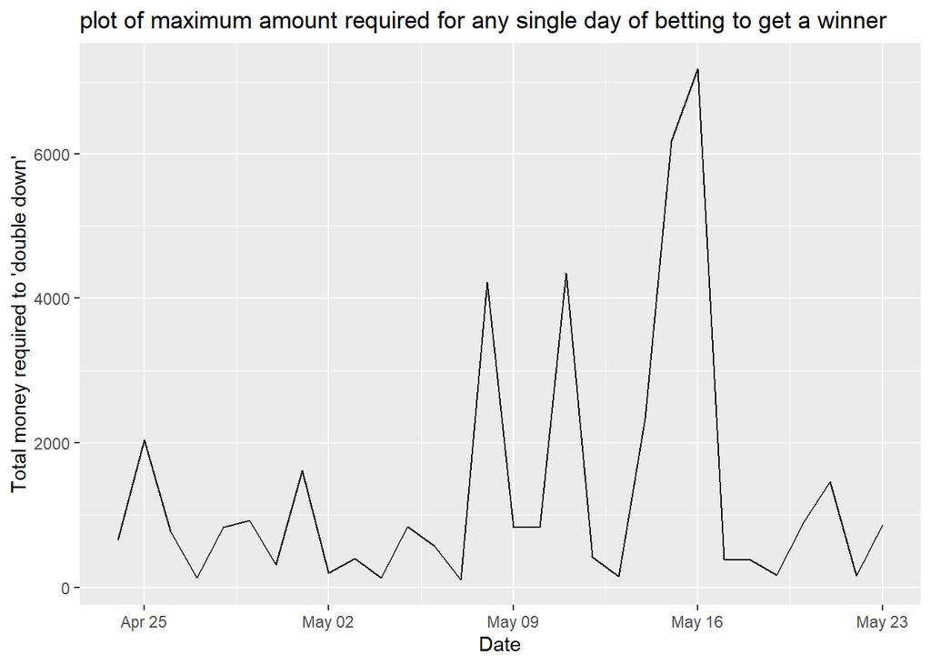

```r
profit_200_daily <- daily_profit_function(all_race_data_clean, 200)
graph_daily_profits(profit_200_daily)
```

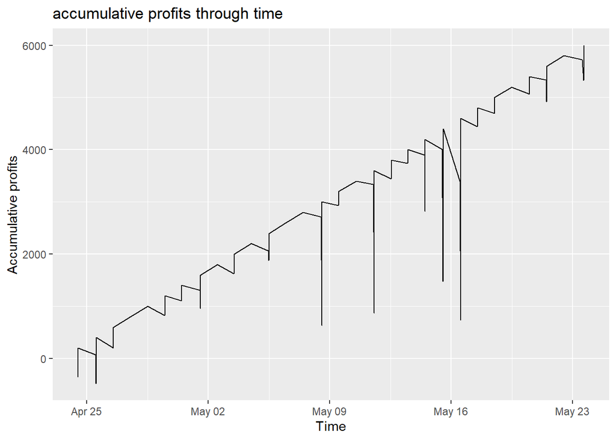

```r
graph_total_profits(profit_200_daily)
```

```r
reactable(profit_system_df_function(profit_200_daily) %>% select(-character,
                                                                -info,
                                                                -race_info))
```

| Finish | No. | Horse | Trainer | Jockey | Margin | Bar. | Weight | Starting.Price | odds | Date_format | State | Racecourse | Race | Day_of_week | distance | track_condition | Margin_Metres | time | RaceID | ID | winner | Race_time | Datetime | favourite | fav_winner | bet | new_bet | total_outlay | profits | … |
| --- | --- | --- | --- | --- | --- | --- | --- | --- | --- | --- | --- | --- | --- | --- | --- | --- | --- | --- | --- | --- | --- | --- | --- | --- | --- | --- | --- | --- | --- | --- |
| 7 | 7 | PIIINK BEAUTY | Glenn Stevenson | Ms Codi Jordan (a0/51kg) | 2.8 | 4 | 55 | $1.55F | 1.55 | 2022-04-24 | TAS | Hobart | Race 1 | Sun | 1200 | Track Condition: Good 4 | 7 | 74.9345833333333 | 2022Apr24,TAS,Hobart , Race 1 | 2022Apr24,TAS,Hobart , Race 1 Finish- 7 | 0 | 11:50AM | 2022-04-24T11:50:00 | 1 | 0 | 1 | 363.636363636364 | 363.636363636364 | -363.636363636364 | … |
| 1 | 10 | BEZIQUE | Tony Gollan | Ben Thompson |  | 8 | 55 | $2.90F | 2.9 | 2022-04-24 | QLD | Sunshine Coast | Race 1 | Sun | 1000 | Track Condition: Soft 7 | 0 | 60.64 | 2022Apr24,QLD,Sunshine Coast , Race 1 | 2022Apr24,QLD,Sunshine Coast , Race 1 Finish- 1 | 1 | 11:55AM | 2022-04-24T11:55:00 | 1 | 1 | 1 | 296.650717703349 | 660.287081339713 | 563.636363636364 | … |
| 3 | 7 | POPPY’S GIRL | Gary Portelli | Ms Alysha Collett | 0.85 | 2 | 55 | $2.50F | 2.5 | 2022-04-25 | NSW | Gosford | Race 1 | Mon | 1200 | Track Condition: Heavy 9 | 2.125 | 74.9124229166667 | 2022Apr25,NSW,Gosford , Race 1 | 2022Apr25,NSW,Gosford , Race 1 Finish- 3 | 0 | 12:29PM | 2022-04-25T12:29:00 | 1 | 0 | 1 | 133.333333333333 | 133.333333333333 | -133.333333333333 | … |
| 4 | 8 | HEADLINER | Chris Waller | James McDonald | 2.06 | 5 | 55 | $2.60F | 2.6 | 2022-04-25 | NSW | Kensington | Race 1 | Mon | 1100 | Track Condition: Heavy 9 | 5.15 | 68.1475677272727 | 2022Apr25,NSW,Kensington , Race 1 | 2022Apr25,NSW,Kensington , Race 1 Finish- 4 | 0 | 12:45PM | 2022-04-25T12:45:00 | 1 | 0 | 1 | 208.333333333333 | 341.666666666667 | -208.333333333333 | … |
| 6 | 2 | ROUSSEAU | Chris Waller | Craig Williams | 17 | 4 | 53 | $2.60F | 2.6 | 2022-04-25 | VIC | Flemington | Race 1 | Mon | 2600 | Track Condition: Good 4 | 42.5 | 165.532298076923 | 2022Apr25,VIC,Flemington , Race 1 | 2022Apr25,VIC,Flemington , Race 1 Finish- 6 | 0 | 1:00PM | 2022-04-25T13:00:00 | 1 | 0 | 1 | 338.541666666667 | 680.208333333333 | -338.541666666667 | … |
| 1 | 6 | MISS MAZ | Gerald Ryan & Sterling Alexiou | Ms Alysha Collett |  | 2 | 56.5 | $1.65F | 1.65 | 2022-04-25 | NSW | Gosford | Race 2 | Mon | 1000 | Track Condition: Heavy 9 | 0 | 61.52 | 2022Apr25,NSW,Gosford , Race 2 | 2022Apr25,NSW,Gosford , Race 2 Finish- 1 | 1 | 1:04PM | 2022-04-25T13:04:00 | 1 | 1 | 1 | 1354.16666666667 | 2034.375 | 880.208333333333 | … |
| 2 | 5 | SKY ACE | Brad Widdup | Ms Alysha Collett | 2 | 3 | 55 | $2F | 2 | 2022-04-26 | NSW | Nowra | Race 1 | Tue | 2200 | Track Condition: Heavy 10 | 5 | 145.820659090909 | 2022Apr26,NSW,Nowra , Race 1 | 2022Apr26,NSW,Nowra , Race 1 Finish- 2 | 0 | 12:55PM | 2022-04-26T12:55:00 | 1 | 0 | 1 | 200 | 200 | -200 | … |
| 1 | 3 | AQUILA VOLARE | Ciaron Maher & David Eustace | Harry Coffey |  | 6 | 59 | $1.70F | 1.7 | 2022-04-26 | VIC | bet365 Mildura | Race 1 | Tue | 2000 | Track Condition: Soft 5 | 0 | 130.23 | 2022Apr26,VIC,bet365 Mildura , Race 1 | 2022Apr26,VIC,bet365 Mildura , Race 1 Finish- 1 | 1 | 1:00PM | 2022-04-26T13:00:00 | 1 | 1 | 1 | 571.428571428571 | 771.428571428571 | 400 | … |
| 1 | 3 | LETHAL THOUGHTS | Ciaron Maher & David Eustace | Ben Allen |  | 3 | 58 | $2.50F | 2.5 | 2022-04-27 | VIC | Sale | Race 1 | Wed | 1206 | Track Condition: Soft 5 | 0 | 71.65 | 2022Apr27,VIC,Sale , Race 1 | 2022Apr27,VIC,Sale , Race 1 Finish- 1 | 1 | 12:25PM | 2022-04-27T12:25:00 | 1 | 1 | 1 | 133.333333333333 | 133.333333333333 | 200 | … |
| 1 | 7 | AFRICAN DAISY | Annabel Neasham | Brodie Loy |  | 6 | 56.5 | $1.24F | 1.24 | 2022-04-28 | NSW | Wyong | Race 1 | Thu | 1350 | Track Condition: Heavy 10 | 0 | 82.32 | 2022Apr28,NSW,Wyong , Race 1 | 2022Apr28,NSW,Wyong , Race 1 Finish- 1 | 1 | 12:20PM | 2022-04-28T12:20:00 | 1 | 1 | 1 | 833.333333333333 | 833.333333333333 | 200 | … |

[output cut: 74 more lines]

From the above you can see that to systematically run a profitable system daily off horse racing, you would need a substantial amount of initial funds however a system like this seems as if it could be run to generate tax free profits.

I am curious if investors with a decent amount of free cash would spend their time betting with a system like this. I am also curious if there are any regulations or rules against betting in a system like shown above, and if gambling companies are testing and assessing their customers habits for systematic attempts to profit off their business?

## Code excluded

### Introduction

This analysis devles into horse racing data, and attempting to identify ways to predict which horse will win, and a potential way to make a profit from betting on horse racing in Australia with reduced risk.

The horse racing data was sourced from the Racing Australia [website](https://www.racingaustralia.horse/Home.aspx) under the racing results tab. The Racing Australia website only stores data for the previous month of races, however it does include trial runs. The race data includes information such as the barrier, weight the horse is carrying, the trainer, the jockey, the date, the track, among many other attributes. The position of the horse at the end of the race, and the length the horse lost by (in lengths) are also included in the data, however lengths is an arbitrary unit of distance, so this was converted to metres by assuming a single horse length was 2.5 metres.

Below shows an example of what the horse racing data initially looks like.

| Finish | No. | Horse | Trainer | Jockey | Margin | Bar. | Weight | Starting Price | character | race_info | info | odds | Date_format | State | Racecourse | Race | Day_of_week | distance | track_condition | winning_time |
| --- | --- | --- | --- | --- | --- | --- | --- | --- | --- | --- | --- | --- | --- | --- | --- | --- | --- | --- | --- | --- |
| 1 | 15 | ANOTHER STAR | David Kelley | Simon Miller |  | 8 | 55 | $17 | Of $24,000.1st $12,280, 2nd $4,440, 3rd $2,300, 4th $1,200, 5th $750, 6th $550, 7th $500, 8th $500, 9th $500, 10th $500, Equine Welfare Fund $240, Jockey Welfare Fund $240. Maiden, Handicap, Minimum W… | Race 2 - 1:05PM SURDEX STEEL ALBURY MAIDEN HANDICAP (1410 METRES) Times displayed in local time of Race Meeting | 2022May23,NSW,Albury | 17 | 2022-05-23 | NSW | Albury | Race 2 | Mon | 1410 | Track Condition: Soft 6 T | 1:26.57 |

After scraping the data, it was decided to convert each horses run into an approximate time estimation, by taking each race’s winning time, and then using the trailing horses distance and estimating their final time by adding time allowing for each horse to cover their losing distance at the winners average speed throughout the race. These times look like this:

| Horse | Jockey | Trainer | distance | Margin | winning_time_total | time |
| --- | --- | --- | --- | --- | --- | --- |
| ANOTHER STAR | Simon Miller | David Kelley | 1410 |  | 86.57 | 86.57 |
| CELLAR CHAMP | Nick Heywood | Gary Colvin | 1410 | 0.9 | 86.57 | 86.7081436170213 |
| LA QUINTA DONNA | Jason Lyon | Mitchell Beer | 1410 | 2.99 | 86.57 | 87.0289437943262 |
| TURNAWAY | Bradley Vale | Chris Heywood | 1410 | 3.21 | 86.57 | 87.0627122340426 |
| ALMANDRA | Ms Kayla Nisbet | Tim Donnelly | 1410 | 3.25 | 86.57 | 87.0688519503546 |
| LES GOH | Quayde Krogh | Barbara Joseph, Paul & Matt Jones | 1410 | 3.31 | 86.57 | 87.0780615248227 |

### Choose a Tab

#### Assessing Favouritism

In this section, a brief assessment of the favouritism is assessed. Specifically, how often the favourite (the horse with the lowet odds at the time of the race) wins.

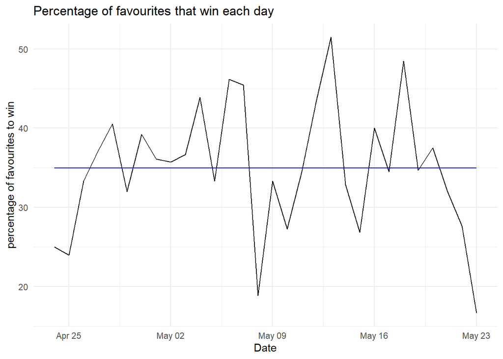

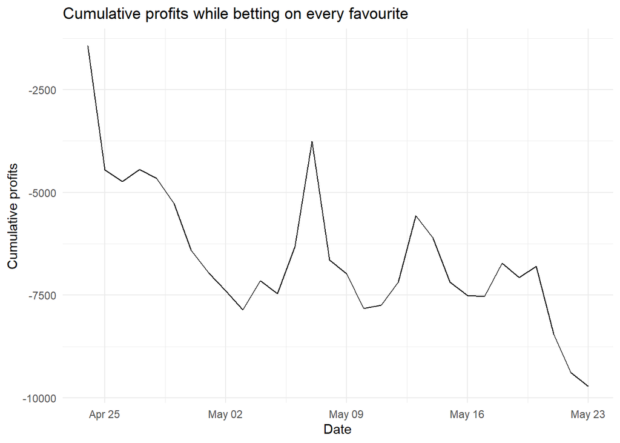

Seeing the variability in cashflows, and that this run ends with losing money, it it not simply enough to rely on the odds of the bookmaker and the public. It is important that we try to predict a winner. To do this initially, a generalized linear model is used to model a winning horse, using important variables such as the barrier, weight, track condition, and distance. Variables such as Horse, Jockey and Trainer have been excluded initially as these variables may only appear once or not at all in the training set, and there is not enough data to include variables that have values occuring once or not at all.

```
Call:
glm(formula = winner ~ Bar. + Weight + track_condition + distance +
    odds, family = binomial, data = train_horse_data)

Deviance Residuals:
    Min       1Q   Median       3Q      Max
-0.7947  -0.5753  -0.3614  -0.0858   6.0570

Coefficients:
                                           Estimate Std. Error z value Pr(>|z|)
(Intercept)                              -1.084e+00  7.661e-01  -1.415    0.157
Bar.                                     -6.294e-03  1.002e-02  -0.628    0.530
Weight                                    2.360e-03  1.307e-02   0.181    0.857
track_conditionTrack Condition: Good 4    7.452e-02  1.818e-01   0.410    0.682
track_conditionTrack Condition: Heavy 10  1.073e-01  2.232e-01   0.481    0.631
track_conditionTrack Condition: Heavy 8   6.763e-02  1.963e-01   0.345    0.730
track_conditionTrack Condition: Heavy 9   6.803e-02  1.954e-01   0.348    0.728
track_conditionTrack Condition: Soft 5    4.689e-02  1.859e-01   0.252    0.801
track_conditionTrack Condition: Soft 6    4.863e-02  1.912e-01   0.254    0.799
track_conditionTrack Condition: Soft 7    7.819e-02  1.919e-01   0.407    0.684
distance                                  2.842e-05  8.357e-05   0.340    0.734
odds                                     -1.153e-01  5.788e-03 -19.913   <2e-16

(Intercept)
Bar.
Weight
track_conditionTrack Condition: Good 4
track_conditionTrack Condition: Heavy 10
track_conditionTrack Condition: Heavy 8
track_conditionTrack Condition: Heavy 9
track_conditionTrack Condition: Soft 5
track_conditionTrack Condition: Soft 6
track_conditionTrack Condition: Soft 7
distance
odds                                     ***
---
Signif. codes:  0 '***' 0.001 '**' 0.01 '*' 0.05 '.' 0.1 ' ' 1

(Dispersion parameter for binomial family taken to be 1)

    Null deviance: 7815.3  on 11776  degrees of freedom
Residual deviance: 6832.6  on 11765  degrees of freedom
AIC: 6856.6

Number of Fisher Scoring iterations: 8
```

After running the GLM, it was found that the GLM’s largest prediction for a horse winning is 26.03%

As the GLM found no way to make any predictions where a horse would win, it was decided that we will try using a random forest to predict some winning horses via classification.

```
Call:
 randomForest(formula = winner ~ Bar. + Weight + track_condition +      distance + odds, data = train_horse_data, importance = TRUE)
               Type of random forest: regression
                     Number of trees: 500
No. of variables tried at each split: 1

          Mean of squared residuals: 0.0836291
                    % Var explained: 9.55
```

Predicted results against actual results

```
   predTrain
      0   1
  0 635   2
  1  63   1
```

| Horse | RaceID | Bar. | Weight | distance | track_condition | odds | winner | bet | profit | roll_total |
| --- | --- | --- | --- | --- | --- | --- | --- | --- | --- | --- |
| MUSIC ADDITION | 2022May22,TAS,Hobart , Race 1 | 3 | 56 | 1100 | Track Condition: Soft 5 | 2.05 | 1 | 95.2380952380953 | 100 | 100 |
| HELLO JACK | 2022May22,NSW,Moruya , Race 2 | 7 | 59 | 1010 | Track Condition: Soft 6 | 2.4 | 0 | 71.4285714285714 | -71.4285714285714 | 28.5714285714286 |
| CALMSIR (NZ) | 2022May22,VIC,Sportsbet-Wangaratta , Race 3 | 6 | 59.5 | 2000 | Track Condition: Soft 5 | 2.2 | 0 | 83.3333333333333 | -83.3333333333333 | -54.7619047619047 |

The Random forest does not predict a lot of horses to win (only 3), however its total accuracy of 90.73% is quite impressive.

We found that this random forest does predict accurately, we were hoping for better in the prediction department. Maybe if we use some machine learning we can get some better predictions. Lets have a look at how a neural network goes with predicting winning horses.

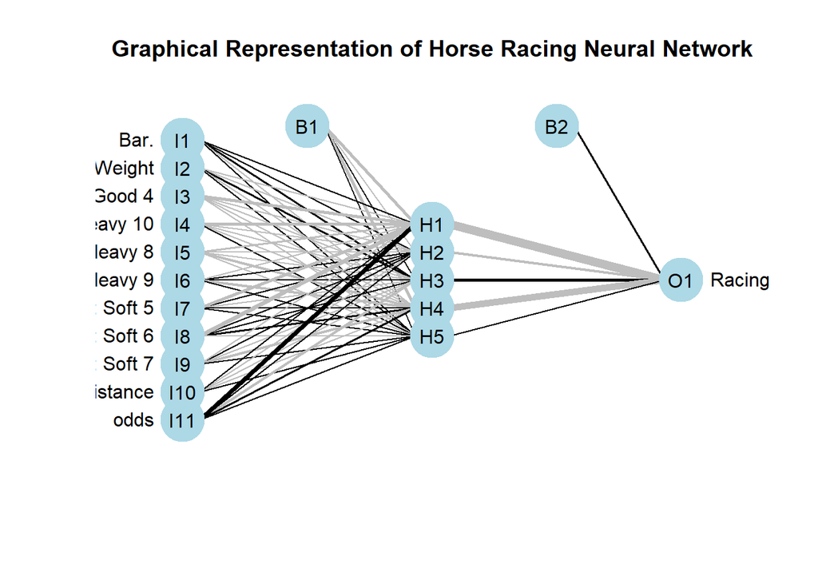

```
   nnet_predictions_test
      0   1
  0 632   5
  1  63   1
```

From the above, we can see that the neural net does predict more horses to win than the random forest, however its prediction of which horses will win is lower than the random forest. When selecting a model to pick a winning horse, a random forest would be used with the chosen variables used.

In future modifications of this analysis, more data will be used and a prediction on time will be analysed using factors such as the horse, trainer and jockey, however as most horses in this data only appear once, training a model on the horse, jockey and trainer is not useful, and may also be biased towards certain trainers and Jockeys who simply train/ride better horses due to their experience and success level (think of Gai Waterhouse and Damian Oliver as examples)

#### Making money

For this to work, the user would need a decent pool of available cash on hand, to sustain increasing bets until a winner pays out and returns all previous bets plus desired winnings. The other most important factor, would be that the better quits after winning their desired amount for that day. This essentially means that if the first favourite wins, the bettor is finished after one race for that day. If it takes 7 races for a favourite to win, the bettor will wager on all 7 races with increasing amounts until a winner emerges resulting in all outlayed bets repayed, along with the desired profit.

Below a simulation on the last months worth of horse racing data has been run, and for different desired winning amounts, the amount of initial funds required obviously varies depending on the desired daily win amount. Below are runs of 50 dollars daily profit, 100 dollars daily profit, and 200 dollars daily profit

##### $50 profit Daily

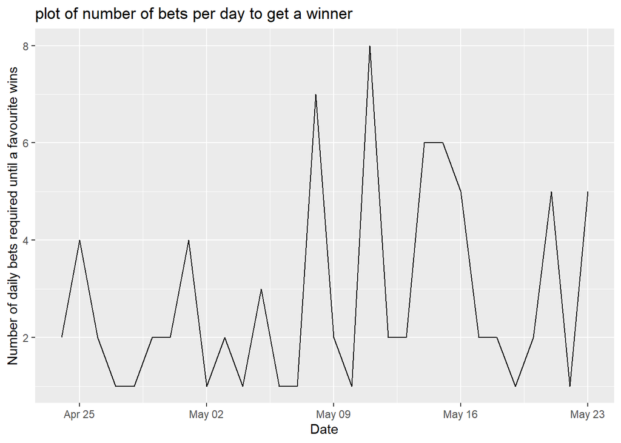

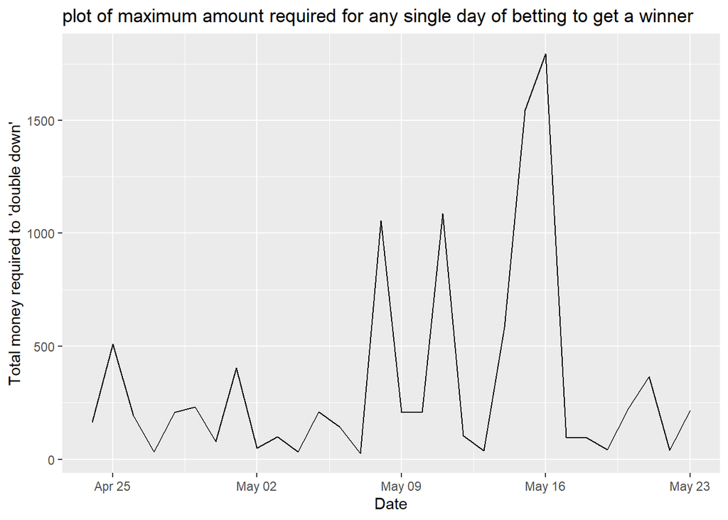

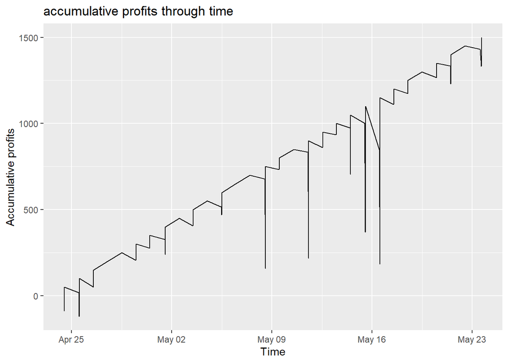

| Finish | No. | Horse | Trainer | Jockey | Margin | Bar. | Weight | Starting.Price | odds | Date_format | State | Racecourse | Race | Day_of_week | distance | track_condition | Margin_Metres | time | RaceID | ID | winner | Race_time | Datetime | favourite | fav_winner | bet | new_bet | total_outlay | profits | … |
| --- | --- | --- | --- | --- | --- | --- | --- | --- | --- | --- | --- | --- | --- | --- | --- | --- | --- | --- | --- | --- | --- | --- | --- | --- | --- | --- | --- | --- | --- | --- |
| 7 | 7 | PIIINK BEAUTY | Glenn Stevenson | Ms Codi Jordan (a0/51kg) | 2.8 | 4 | 55 | $1.55F | 1.55 | 2022-04-24 | TAS | Hobart | Race 1 | Sun | 1200 | Track Condition: Good 4 | 7 | 74.9345833333333 | 2022Apr24,TAS,Hobart , Race 1 | 2022Apr24,TAS,Hobart , Race 1 Finish- 7 | 0 | 11:50AM | 2022-04-24T11:50:00 | 1 | 0 | 1 | 90.9090909090909 | 90.9090909090909 | -90.9090909090909 | … |
| 1 | 10 | BEZIQUE | Tony Gollan | Ben Thompson |  | 8 | 55 | $2.90F | 2.9 | 2022-04-24 | QLD | Sunshine Coast | Race 1 | Sun | 1000 | Track Condition: Soft 7 | 0 | 60.64 | 2022Apr24,QLD,Sunshine Coast , Race 1 | 2022Apr24,QLD,Sunshine Coast , Race 1 Finish- 1 | 1 | 11:55AM | 2022-04-24T11:55:00 | 1 | 1 | 1 | 74.1626794258373 | 165.071770334928 | 140.909090909091 | … |
| 3 | 7 | POPPY’S GIRL | Gary Portelli | Ms Alysha Collett | 0.85 | 2 | 55 | $2.50F | 2.5 | 2022-04-25 | NSW | Gosford | Race 1 | Mon | 1200 | Track Condition: Heavy 9 | 2.125 | 74.9124229166667 | 2022Apr25,NSW,Gosford , Race 1 | 2022Apr25,NSW,Gosford , Race 1 Finish- 3 | 0 | 12:29PM | 2022-04-25T12:29:00 | 1 | 0 | 1 | 33.3333333333333 | 33.3333333333333 | -33.3333333333333 | … |
| 4 | 8 | HEADLINER | Chris Waller | James McDonald | 2.06 | 5 | 55 | $2.60F | 2.6 | 2022-04-25 | NSW | Kensington | Race 1 | Mon | 1100 | Track Condition: Heavy 9 | 5.15 | 68.1475677272727 | 2022Apr25,NSW,Kensington , Race 1 | 2022Apr25,NSW,Kensington , Race 1 Finish- 4 | 0 | 12:45PM | 2022-04-25T12:45:00 | 1 | 0 | 1 | 52.0833333333333 | 85.4166666666667 | -52.0833333333333 | … |
| 6 | 2 | ROUSSEAU | Chris Waller | Craig Williams | 17 | 4 | 53 | $2.60F | 2.6 | 2022-04-25 | VIC | Flemington | Race 1 | Mon | 2600 | Track Condition: Good 4 | 42.5 | 165.532298076923 | 2022Apr25,VIC,Flemington , Race 1 | 2022Apr25,VIC,Flemington , Race 1 Finish- 6 | 0 | 1:00PM | 2022-04-25T13:00:00 | 1 | 0 | 1 | 84.6354166666667 | 170.052083333333 | -84.6354166666667 | … |
| 1 | 6 | MISS MAZ | Gerald Ryan & Sterling Alexiou | Ms Alysha Collett |  | 2 | 56.5 | $1.65F | 1.65 | 2022-04-25 | NSW | Gosford | Race 2 | Mon | 1000 | Track Condition: Heavy 9 | 0 | 61.52 | 2022Apr25,NSW,Gosford , Race 2 | 2022Apr25,NSW,Gosford , Race 2 Finish- 1 | 1 | 1:04PM | 2022-04-25T13:04:00 | 1 | 1 | 1 | 338.541666666667 | 508.59375 | 220.052083333333 | … |
| 2 | 5 | SKY ACE | Brad Widdup | Ms Alysha Collett | 2 | 3 | 55 | $2F | 2 | 2022-04-26 | NSW | Nowra | Race 1 | Tue | 2200 | Track Condition: Heavy 10 | 5 | 145.820659090909 | 2022Apr26,NSW,Nowra , Race 1 | 2022Apr26,NSW,Nowra , Race 1 Finish- 2 | 0 | 12:55PM | 2022-04-26T12:55:00 | 1 | 0 | 1 | 50 | 50 | -50 | … |
| 1 | 3 | AQUILA VOLARE | Ciaron Maher & David Eustace | Harry Coffey |  | 6 | 59 | $1.70F | 1.7 | 2022-04-26 | VIC | bet365 Mildura | Race 1 | Tue | 2000 | Track Condition: Soft 5 | 0 | 130.23 | 2022Apr26,VIC,bet365 Mildura , Race 1 | 2022Apr26,VIC,bet365 Mildura , Race 1 Finish- 1 | 1 | 1:00PM | 2022-04-26T13:00:00 | 1 | 1 | 1 | 142.857142857143 | 192.857142857143 | 100 | … |
| 1 | 3 | LETHAL THOUGHTS | Ciaron Maher & David Eustace | Ben Allen |  | 3 | 58 | $2.50F | 2.5 | 2022-04-27 | VIC | Sale | Race 1 | Wed | 1206 | Track Condition: Soft 5 | 0 | 71.65 | 2022Apr27,VIC,Sale , Race 1 | 2022Apr27,VIC,Sale , Race 1 Finish- 1 | 1 | 12:25PM | 2022-04-27T12:25:00 | 1 | 1 | 1 | 33.3333333333333 | 33.3333333333333 | 50 | … |
| 1 | 7 | AFRICAN DAISY | Annabel Neasham | Brodie Loy |  | 6 | 56.5 | $1.24F | 1.24 | 2022-04-28 | NSW | Wyong | Race 1 | Thu | 1350 | Track Condition: Heavy 10 | 0 | 82.32 | 2022Apr28,NSW,Wyong , Race 1 | 2022Apr28,NSW,Wyong , Race 1 Finish- 1 | 1 | 12:20PM | 2022-04-28T12:20:00 | 1 | 1 | 1 | 208.333333333333 | 208.333333333333 | 50 | … |

[output cut: 74 more lines]

##### $100 profit Daily

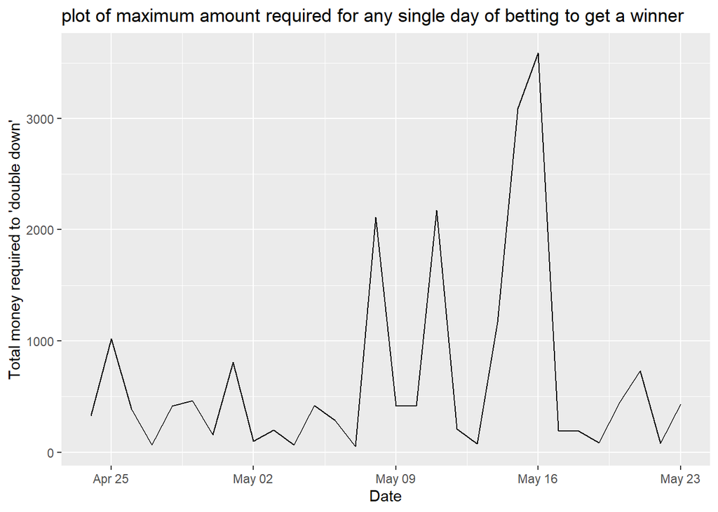

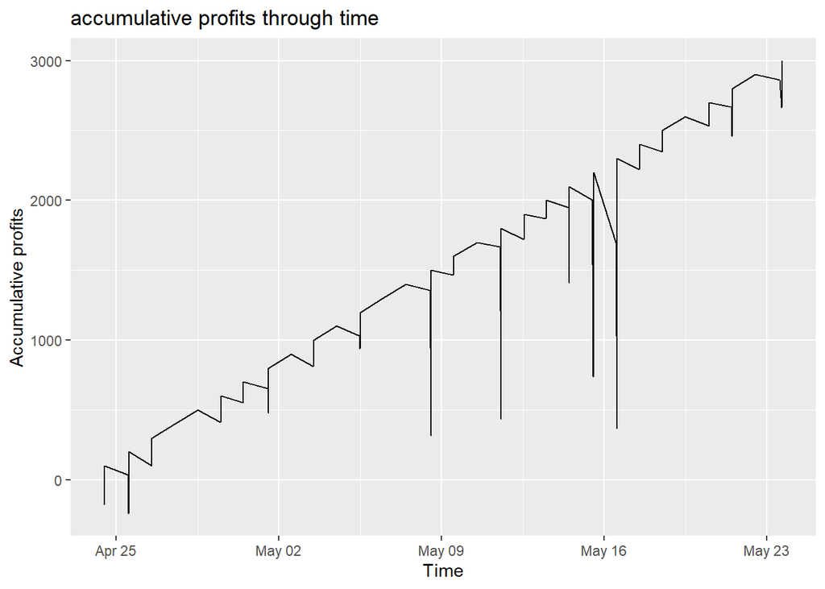

| Finish | No. | Horse | Trainer | Jockey | Margin | Bar. | Weight | Starting.Price | odds | Date_format | State | Racecourse | Race | Day_of_week | distance | track_condition | Margin_Metres | time | RaceID | ID | winner | Race_time | Datetime | favourite | fav_winner | bet | new_bet | total_outlay | profits | … |
| --- | --- | --- | --- | --- | --- | --- | --- | --- | --- | --- | --- | --- | --- | --- | --- | --- | --- | --- | --- | --- | --- | --- | --- | --- | --- | --- | --- | --- | --- | --- |
| 7 | 7 | PIIINK BEAUTY | Glenn Stevenson | Ms Codi Jordan (a0/51kg) | 2.8 | 4 | 55 | $1.55F | 1.55 | 2022-04-24 | TAS | Hobart | Race 1 | Sun | 1200 | Track Condition: Good 4 | 7 | 74.9345833333333 | 2022Apr24,TAS,Hobart , Race 1 | 2022Apr24,TAS,Hobart , Race 1 Finish- 7 | 0 | 11:50AM | 2022-04-24T11:50:00 | 1 | 0 | 1 | 181.818181818182 | 181.818181818182 | -181.818181818182 | … |
| 1 | 10 | BEZIQUE | Tony Gollan | Ben Thompson |  | 8 | 55 | $2.90F | 2.9 | 2022-04-24 | QLD | Sunshine Coast | Race 1 | Sun | 1000 | Track Condition: Soft 7 | 0 | 60.64 | 2022Apr24,QLD,Sunshine Coast , Race 1 | 2022Apr24,QLD,Sunshine Coast , Race 1 Finish- 1 | 1 | 11:55AM | 2022-04-24T11:55:00 | 1 | 1 | 1 | 148.325358851675 | 330.143540669856 | 281.818181818182 | … |
| 3 | 7 | POPPY’S GIRL | Gary Portelli | Ms Alysha Collett | 0.85 | 2 | 55 | $2.50F | 2.5 | 2022-04-25 | NSW | Gosford | Race 1 | Mon | 1200 | Track Condition: Heavy 9 | 2.125 | 74.9124229166667 | 2022Apr25,NSW,Gosford , Race 1 | 2022Apr25,NSW,Gosford , Race 1 Finish- 3 | 0 | 12:29PM | 2022-04-25T12:29:00 | 1 | 0 | 1 | 66.6666666666667 | 66.6666666666667 | -66.6666666666667 | … |
| 4 | 8 | HEADLINER | Chris Waller | James McDonald | 2.06 | 5 | 55 | $2.60F | 2.6 | 2022-04-25 | NSW | Kensington | Race 1 | Mon | 1100 | Track Condition: Heavy 9 | 5.15 | 68.1475677272727 | 2022Apr25,NSW,Kensington , Race 1 | 2022Apr25,NSW,Kensington , Race 1 Finish- 4 | 0 | 12:45PM | 2022-04-25T12:45:00 | 1 | 0 | 1 | 104.166666666667 | 170.833333333333 | -104.166666666667 | … |
| 6 | 2 | ROUSSEAU | Chris Waller | Craig Williams | 17 | 4 | 53 | $2.60F | 2.6 | 2022-04-25 | VIC | Flemington | Race 1 | Mon | 2600 | Track Condition: Good 4 | 42.5 | 165.532298076923 | 2022Apr25,VIC,Flemington , Race 1 | 2022Apr25,VIC,Flemington , Race 1 Finish- 6 | 0 | 1:00PM | 2022-04-25T13:00:00 | 1 | 0 | 1 | 169.270833333333 | 340.104166666667 | -169.270833333333 | … |
| 1 | 6 | MISS MAZ | Gerald Ryan & Sterling Alexiou | Ms Alysha Collett |  | 2 | 56.5 | $1.65F | 1.65 | 2022-04-25 | NSW | Gosford | Race 2 | Mon | 1000 | Track Condition: Heavy 9 | 0 | 61.52 | 2022Apr25,NSW,Gosford , Race 2 | 2022Apr25,NSW,Gosford , Race 2 Finish- 1 | 1 | 1:04PM | 2022-04-25T13:04:00 | 1 | 1 | 1 | 677.083333333333 | 1017.1875 | 440.104166666667 | … |
| 2 | 5 | SKY ACE | Brad Widdup | Ms Alysha Collett | 2 | 3 | 55 | $2F | 2 | 2022-04-26 | NSW | Nowra | Race 1 | Tue | 2200 | Track Condition: Heavy 10 | 5 | 145.820659090909 | 2022Apr26,NSW,Nowra , Race 1 | 2022Apr26,NSW,Nowra , Race 1 Finish- 2 | 0 | 12:55PM | 2022-04-26T12:55:00 | 1 | 0 | 1 | 100 | 100 | -100 | … |
| 1 | 3 | AQUILA VOLARE | Ciaron Maher & David Eustace | Harry Coffey |  | 6 | 59 | $1.70F | 1.7 | 2022-04-26 | VIC | bet365 Mildura | Race 1 | Tue | 2000 | Track Condition: Soft 5 | 0 | 130.23 | 2022Apr26,VIC,bet365 Mildura , Race 1 | 2022Apr26,VIC,bet365 Mildura , Race 1 Finish- 1 | 1 | 1:00PM | 2022-04-26T13:00:00 | 1 | 1 | 1 | 285.714285714286 | 385.714285714286 | 200 | … |
| 1 | 3 | LETHAL THOUGHTS | Ciaron Maher & David Eustace | Ben Allen |  | 3 | 58 | $2.50F | 2.5 | 2022-04-27 | VIC | Sale | Race 1 | Wed | 1206 | Track Condition: Soft 5 | 0 | 71.65 | 2022Apr27,VIC,Sale , Race 1 | 2022Apr27,VIC,Sale , Race 1 Finish- 1 | 1 | 12:25PM | 2022-04-27T12:25:00 | 1 | 1 | 1 | 66.6666666666667 | 66.6666666666667 | 100 | … |
| 1 | 7 | AFRICAN DAISY | Annabel Neasham | Brodie Loy |  | 6 | 56.5 | $1.24F | 1.24 | 2022-04-28 | NSW | Wyong | Race 1 | Thu | 1350 | Track Condition: Heavy 10 | 0 | 82.32 | 2022Apr28,NSW,Wyong , Race 1 | 2022Apr28,NSW,Wyong , Race 1 Finish- 1 | 1 | 12:20PM | 2022-04-28T12:20:00 | 1 | 1 | 1 | 416.666666666667 | 416.666666666667 | 100 | … |

[output cut: 74 more lines]

##### $200 profit Daily

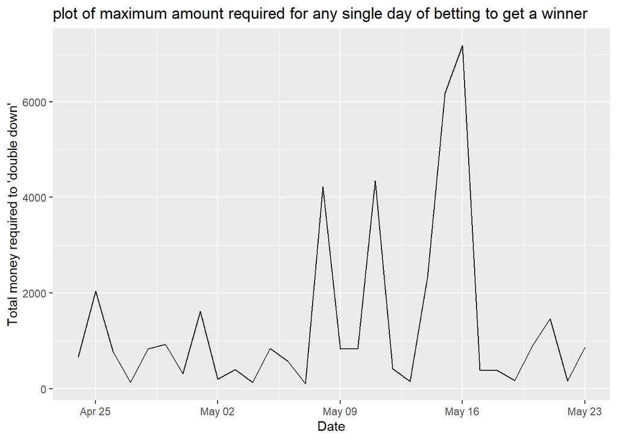

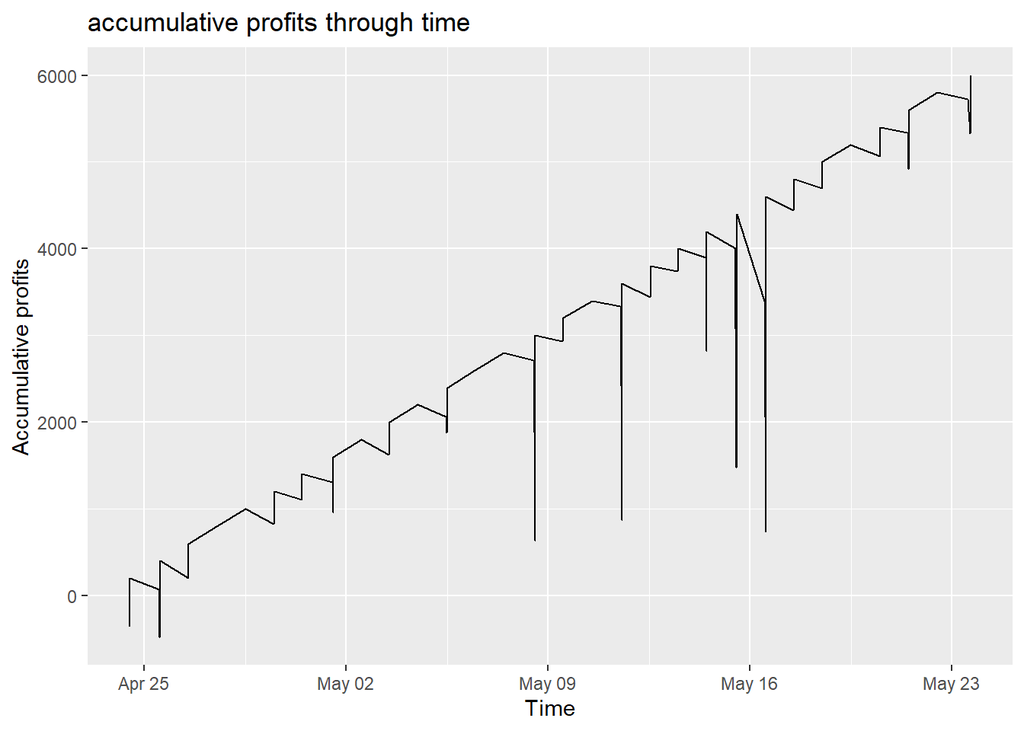

| Finish | No. | Horse | Trainer | Jockey | Margin | Bar. | Weight | Starting.Price | odds | Date_format | State | Racecourse | Race | Day_of_week | distance | track_condition | Margin_Metres | time | RaceID | ID | winner | Race_time | Datetime | favourite | fav_winner | bet | new_bet | total_outlay | profits | … |
| --- | --- | --- | --- | --- | --- | --- | --- | --- | --- | --- | --- | --- | --- | --- | --- | --- | --- | --- | --- | --- | --- | --- | --- | --- | --- | --- | --- | --- | --- | --- |
| 7 | 7 | PIIINK BEAUTY | Glenn Stevenson | Ms Codi Jordan (a0/51kg) | 2.8 | 4 | 55 | $1.55F | 1.55 | 2022-04-24 | TAS | Hobart | Race 1 | Sun | 1200 | Track Condition: Good 4 | 7 | 74.9345833333333 | 2022Apr24,TAS,Hobart , Race 1 | 2022Apr24,TAS,Hobart , Race 1 Finish- 7 | 0 | 11:50AM | 2022-04-24T11:50:00 | 1 | 0 | 1 | 363.636363636364 | 363.636363636364 | -363.636363636364 | … |
| 1 | 10 | BEZIQUE | Tony Gollan | Ben Thompson |  | 8 | 55 | $2.90F | 2.9 | 2022-04-24 | QLD | Sunshine Coast | Race 1 | Sun | 1000 | Track Condition: Soft 7 | 0 | 60.64 | 2022Apr24,QLD,Sunshine Coast , Race 1 | 2022Apr24,QLD,Sunshine Coast , Race 1 Finish- 1 | 1 | 11:55AM | 2022-04-24T11:55:00 | 1 | 1 | 1 | 296.650717703349 | 660.287081339713 | 563.636363636364 | … |
| 3 | 7 | POPPY’S GIRL | Gary Portelli | Ms Alysha Collett | 0.85 | 2 | 55 | $2.50F | 2.5 | 2022-04-25 | NSW | Gosford | Race 1 | Mon | 1200 | Track Condition: Heavy 9 | 2.125 | 74.9124229166667 | 2022Apr25,NSW,Gosford , Race 1 | 2022Apr25,NSW,Gosford , Race 1 Finish- 3 | 0 | 12:29PM | 2022-04-25T12:29:00 | 1 | 0 | 1 | 133.333333333333 | 133.333333333333 | -133.333333333333 | … |
| 4 | 8 | HEADLINER | Chris Waller | James McDonald | 2.06 | 5 | 55 | $2.60F | 2.6 | 2022-04-25 | NSW | Kensington | Race 1 | Mon | 1100 | Track Condition: Heavy 9 | 5.15 | 68.1475677272727 | 2022Apr25,NSW,Kensington , Race 1 | 2022Apr25,NSW,Kensington , Race 1 Finish- 4 | 0 | 12:45PM | 2022-04-25T12:45:00 | 1 | 0 | 1 | 208.333333333333 | 341.666666666667 | -208.333333333333 | … |
| 6 | 2 | ROUSSEAU | Chris Waller | Craig Williams | 17 | 4 | 53 | $2.60F | 2.6 | 2022-04-25 | VIC | Flemington | Race 1 | Mon | 2600 | Track Condition: Good 4 | 42.5 | 165.532298076923 | 2022Apr25,VIC,Flemington , Race 1 | 2022Apr25,VIC,Flemington , Race 1 Finish- 6 | 0 | 1:00PM | 2022-04-25T13:00:00 | 1 | 0 | 1 | 338.541666666667 | 680.208333333333 | -338.541666666667 | … |
| 1 | 6 | MISS MAZ | Gerald Ryan & Sterling Alexiou | Ms Alysha Collett |  | 2 | 56.5 | $1.65F | 1.65 | 2022-04-25 | NSW | Gosford | Race 2 | Mon | 1000 | Track Condition: Heavy 9 | 0 | 61.52 | 2022Apr25,NSW,Gosford , Race 2 | 2022Apr25,NSW,Gosford , Race 2 Finish- 1 | 1 | 1:04PM | 2022-04-25T13:04:00 | 1 | 1 | 1 | 1354.16666666667 | 2034.375 | 880.208333333333 | … |
| 2 | 5 | SKY ACE | Brad Widdup | Ms Alysha Collett | 2 | 3 | 55 | $2F | 2 | 2022-04-26 | NSW | Nowra | Race 1 | Tue | 2200 | Track Condition: Heavy 10 | 5 | 145.820659090909 | 2022Apr26,NSW,Nowra , Race 1 | 2022Apr26,NSW,Nowra , Race 1 Finish- 2 | 0 | 12:55PM | 2022-04-26T12:55:00 | 1 | 0 | 1 | 200 | 200 | -200 | … |
| 1 | 3 | AQUILA VOLARE | Ciaron Maher & David Eustace | Harry Coffey |  | 6 | 59 | $1.70F | 1.7 | 2022-04-26 | VIC | bet365 Mildura | Race 1 | Tue | 2000 | Track Condition: Soft 5 | 0 | 130.23 | 2022Apr26,VIC,bet365 Mildura , Race 1 | 2022Apr26,VIC,bet365 Mildura , Race 1 Finish- 1 | 1 | 1:00PM | 2022-04-26T13:00:00 | 1 | 1 | 1 | 571.428571428571 | 771.428571428571 | 400 | … |
| 1 | 3 | LETHAL THOUGHTS | Ciaron Maher & David Eustace | Ben Allen |  | 3 | 58 | $2.50F | 2.5 | 2022-04-27 | VIC | Sale | Race 1 | Wed | 1206 | Track Condition: Soft 5 | 0 | 71.65 | 2022Apr27,VIC,Sale , Race 1 | 2022Apr27,VIC,Sale , Race 1 Finish- 1 | 1 | 12:25PM | 2022-04-27T12:25:00 | 1 | 1 | 1 | 133.333333333333 | 133.333333333333 | 200 | … |
| 1 | 7 | AFRICAN DAISY | Annabel Neasham | Brodie Loy |  | 6 | 56.5 | $1.24F | 1.24 | 2022-04-28 | NSW | Wyong | Race 1 | Thu | 1350 | Track Condition: Heavy 10 | 0 | 82.32 | 2022Apr28,NSW,Wyong , Race 1 | 2022Apr28,NSW,Wyong , Race 1 Finish- 1 | 1 | 12:20PM | 2022-04-28T12:20:00 | 1 | 1 | 1 | 833.333333333333 | 833.333333333333 | 200 | … |

[output cut: 74 more lines]

From the above you can see that to systematically run a profitable system daily off horse racing, you would need a substantial amount of initial funds however a system like this seems as if it could be run to generate tax free profits.

I am curious if investors with a decent amount of free cash would spend their time betting with a system like this. I am also curious if there are any regulations or rules against betting in a system like shown above, and if gambling companies are testing and assessing their customers habits for systematic attempts to profit off their business?